# Michelson Speed-of-light Measurements

- Grading Rubric
  - Individual
  - Team
  - Due Date
  - Bibliography

*Purpose*: When studying physical problems, there is an important distinction between *error* and *uncertainty*. The primary purpose of this challenge is to dip our toes into these factors by analyzing a real dataset.

*Reading*: [Experimental Determination of the Velocity of Light](https://play.google.com/books/reader?id=343nAAAAMAAJ&hl=en&pg=GBS.PA115) (Optional)

# Grading Rubric

Unlike exercises, **challenges will be graded**. The following rubrics define how you will be graded, both on an individual and team basis.

## Individual

| Category | Unsatisfactory | Satisfactory |
| --- | --- | --- |
| Effort | Some task **q**’s left unattempted | All task **q**’s attempted |
| Observed | Did not document observations | Documented observations based on analysis |
| Supported | Some observations not supported by analysis | All observations supported by analysis (table, graph, etc.) |
| Code Styled | Violations of the [style guide](https://style.tidyverse.org/) hinder readability | Code sufficiently close to the [style guide](https://style.tidyverse.org/) |

## Team

| Category | Unsatisfactory | Satisfactory |
| --- | --- | --- |
| Documented | No team contributions to Wiki | Team contributed to Wiki |
| Referenced | No team references in Wiki | At least one reference in Wiki to member report(s) |
| Relevant | References unrelated to assertion, or difficult to find related analysis based on reference text | Reference text clearly points to relevant analysis |

## Due Date

All the deliverables stated in the rubrics above are due on the day of the class discussion of that exercise. See the [Syllabus](https://docs.google.com/document/d/1jJTh2DH8nVJd2eyMMoyNGroReo0BKcJrz1eONi3rPSc/edit?usp=sharing) for more information.

```r
# Libraries
library(tidyverse)
library(googlesheets4)

url <- "https://docs.google.com/spreadsheets/d/1av_SXn4j0-4Rk0mQFik3LLr-uf0YdA06i3ugE6n-Zdo/edit?usp=sharing"

# Parameters
LIGHTSPEED_VACUUM    <- 299792.458 # Exact speed of light in a vacuum (km / s)
LIGHTSPEED_MICHELSON <- 299944.00  # Michelson's speed estimate (km / s)
LIGHTSPEED_PM        <- 51         # Michelson error estimate (km / s)
```

I’ve already copied Michelson’s data from his 1880 publication; the code chunk below will load these data from a public googlesheet.

*Aside*: The speed of light is *exact* (there is **zero error** in the value `LIGHTSPEED_VACUUM`) because the meter is actually [*defined*](https://en.wikipedia.org/wiki/Metre#Speed_of_light_definition) in terms of the speed of light!

```r
## Note: No need to edit this chunk!
gs4_deauth()
ss <- gs4_get(url)
df_michelson <-
  read_sheet(ss) %>%
  select(Date, Distinctness, Temp, Velocity) %>%
  mutate(Distinctness = as_factor(Distinctness))
```

```
## Reading from "michelson1879"

## Range "Sheet1"
```

```r
df_michelson %>% glimpse
```

```
## Rows: 100
## Columns: 4
## $ Date         <dttm> 1879-06-05, 1879-06-07, 1879-06-07, 1879-06-07, 1879-06…
## $ Distinctness <fct> 3, 2, 2, 2, 2, 2, 3, 3, 3, 3, 2, 2, 2, 2, 2, 1, 3, 3, 2,…
## $ Temp         <dbl> 76, 72, 72, 72, 72, 72, 83, 83, 83, 83, 83, 90, 90, 71, …
## $ Velocity     <dbl> 299850, 299740, 299900, 300070, 299930, 299850, 299950, …
```

*Data dictionary*:

- `Date`: Date of measurement
- `Distinctness`: Distinctness of measured images: 3 = good, 2 = fair, 1 = poor
- `Temp`: Ambient temperature (Fahrenheit)
- `Velocity`: Measured speed of light (km / s)

**q1** Re-create the following table (from Michelson (1880), pg. 139) using `df_michelson` and `dplyr`. Note that your values *will not* match those of Michelson *exactly*; why might this be?

| Distinctness | n | MeanVelocity |
| --- | --- | --- |
| 3 | 46 | 299860 |
| 2 | 39 | 299860 |
| 1 | 15 | 299810 |

```r
## TODO: Compute summaries
df_michelson %>%
  group_by(Distinctness) %>%
  summarize(n = n(), MeanVelocity = mean(Velocity)) %>%
  arrange(desc(Distinctness)) %>%
  knitr::kable()
```

| Distinctness | n | MeanVelocity |
| --- | --- | --- |
| 3 | 46 | 299861.7 |
| 2 | 39 | 299858.5 |
| 1 | 15 | 299808.0 |

**Observations**: - Write your observations here! - Why might your table differ from Michelson’s?

- The observed differences are tiny in reference to the scale of the entire number. The differences range from -1.7 to 2.0 against a very large number, around 0.0006% of the value’s total.
- I notice that his given values are all rounded to values of 10, maybe there was something going on like significant figures or measurement accuracy where it wasn’t appropriate to claim something more accurate?
- It’s possible that as part of the hand calculations he made an error, though from context that seems unlikely.
- It’s possible that part of the hand calculations for such large numbers involved a small amount of approximation?

The `Velocity` values in the dataset are the speed of light *in air*; Michelson introduced a couple of adjustments to estimate the speed of light in a vacuum. In total, he added $+92$ km/s to his mean estimate for `VelocityVacuum` (from Michelson (1880), pg. 141). While this isn’t fully rigorous ($+92$ km/s is based on the mean temperature), we’ll simply apply this correction to all the observations in the dataset.

**q2** Create a new variable `VelocityVacuum` with the $+92$ km/s adjustment to `Velocity`. Assign this new dataframe to `df_q2`.

```r
## TODO: Adjust the data, assign to df_q2
df_q2 <- df_michelson %>%
  mutate(
    VelocityVacuum = Velocity + 92,
    error = LIGHTSPEED_VACUUM - VelocityVacuum,
  )
df_q2
```

```
## # A tibble: 100 x 6
##    Date                Distinctness  Temp Velocity VelocityVacuum  error
##    <dttm>              <fct>        <dbl>    <dbl>          <dbl>  <dbl>
##  1 1879-06-05 00:00:00 3               76   299850         299942 -150.
##  2 1879-06-07 00:00:00 2               72   299740         299832  -39.5
##  3 1879-06-07 00:00:00 2               72   299900         299992 -200.
##  4 1879-06-07 00:00:00 2               72   300070         300162 -370.
##  5 1879-06-07 00:00:00 2               72   299930         300022 -230.
##  6 1879-06-07 00:00:00 2               72   299850         299942 -150.
##  7 1879-06-09 00:00:00 3               83   299950         300042 -250.
##  8 1879-06-09 00:00:00 3               83   299980         300072 -280.
##  9 1879-06-09 00:00:00 3               83   299980         300072 -280.
## 10 1879-06-09 00:00:00 3               83   299880         299972 -180.
## # … with 90 more rows
```

As part of his study, Michelson assessed the various potential sources of error, and provided his best-guess for the error in his speed-of-light estimate. These values are provided in `LIGHTSPEED_MICHELSON`—his nominal estimate—and `LIGHTSPEED_PM`—plus/minus bounds on his estimate. Put differently, Michelson believed the true value of the speed-of-light probably lay between `LIGHTSPEED_MICHELSON - LIGHTSPEED_PM` and `LIGHTSPEED_MICHELSON + LIGHTSPEED_PM`.

Let’s introduce some terminology:
$$2$$

- **Error** is the difference between a true value and an estimate of that value; for instance `LIGHTSPEED_VACUUM - LIGHTSPEED_MICHELSON`.
- **Uncertainty** is an analyst’s *assessment* of the error.

Since a “true” value is often not known in practice, one generally does not know the error. The best they can do is quantify their degree of uncertainty. We will learn some means of quantifying uncertainty in this class, but for many real problems uncertainty includes some amount of human judgment.
$$2$$

**q3** Compare Michelson’s speed of light estimate against the modern speed of light value. Is Michelson’s estimate of the error (his uncertainty) greater or less than the true error?

```r
error <- LIGHTSPEED_VACUUM - LIGHTSPEED_MICHELSON
uncertainty <- LIGHTSPEED_PM
df_michelson %>%
  summarize(
    true = LIGHTSPEED_VACUUM,
    estimate = LIGHTSPEED_MICHELSON,
    error = error,
    uncertainty = uncertainty,
    was_he_good = abs(uncertainty) > abs(error)
  )
```

```
## # A tibble: 1 x 5
##      true estimate error uncertainty was_he_good
##     <dbl>    <dbl> <dbl>       <dbl> <lgl>
## 1 299792.   299944 -152.          51 FALSE
```

**Observations**:

- Michelson’s uncertainty (~50) was less that the true error (~150). The error here is negative because the true value is less than his estimate. Still pretty impressive, compared to the full scale of the number he is not wrong by a large fraction.

**q4** You have access to a few other variables. Construct a few visualizations of `VelocityVacuum` against these other factors. Are there other patterns in the data that might help explain the difference between Michelson’s estimate and `LIGHTSPEED_VACUUM`?

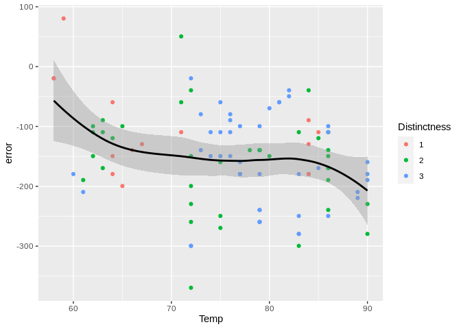

```r
df_q2 %>%
  ggplot() +
    geom_point(aes(x = Temp, y = error, color = Distinctness)) +
    geom_smooth(aes(x = Temp, y = error), color = "black")
```

- You can see a faint pattern in distinctness over temperature. The level 3 distinctness (best, blue) appears to favor the right (warmer) side of the graph. The level 1 distinctness (worst, pink) appears to favor the left (colder) side of the graph. Level 2 distinctness is scattered throughout.
- Now the question is - did distinctness lead to better measurements? We know it didn’t lead to closeness to the real value (since the lower temperatures were slightly closer to the real value) but we can inspect if high distinctness led to tighter values.

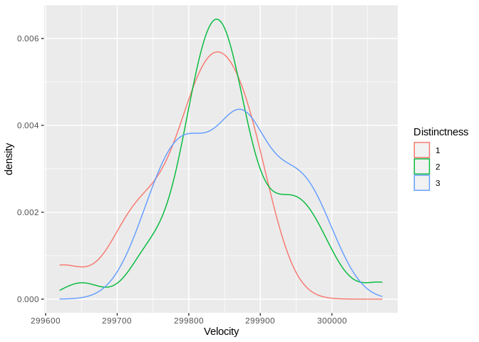

```r
df_q2 %>%
  ggplot() +
    geom_density(aes(x = Velocity, color = Distinctness))
```

- In general, higher quality measurements will correspond to tighter densities around the mean, even if some systematic error keeps that mean away from the true value being measured. In this case it appears that distinctness is not a good proxy for measurement quality. The “highly distinct” measurements (level 3) are the least tight of the measurements, where lv.2 is the tightest and lv.1 holds the middle spot. If Michelson was weighting distinct measurement more strongly without them being better measurements, that’s a source of error. It seems like it would just lead to higher than expected randomness.
- Other than this reliance on what appears to be a faulty proxy for quality, I don’t see any patterns jumping out that would lead to the poor measurement. It seems like there was some systematic error that bumped his measurement too high, as the whole cloud of measurements appears to be centered ~150 km/s off.

## Bibliography

- $$1$$
  Michelson, [Experimental Determination of the Velocity of Light](https://play.google.com/books/reader?id=343nAAAAMAAJ&hl=en&pg=GBS.PA115)
- $$2$$
  Henrion and Fischhoff, [Assessing Uncertainty in Physical Constants](https://www.cmu.edu/epp/people/faculty/research/Fischoff-Henrion-Assessing%20uncertainty%20in%20physical%20constants.pdf)